Skip to main content

# Global Patterns in Reported Human Rabies Deaths (2010–2024)

- Show All Code
- Hide All Code
- View Source

Reported deaths, population, and GDP per capita

Author

Angelo Vescio

Published

November 11, 2026

## 1 Introduction

Rabies is a zoonotic viral disease caused by the rabies virus (RV). RV is a negative sense single stranded RNA virus of the rhabdovirus family that primarily infects the central nervous system of mammals. Rabies, when contracted and once clinical symptoms develop, is almost universally fatal. Rabies can be transmitted through several routes, although bites from infected animals are by far the most common mode of transmission. Following a bite, virus-containing saliva enters the victim’s skeletal muscle, where viral replication begins. The virus then enters motor neurons through neuromuscular junctions and travels between neurons via synaptic connections until it reaches the central nervous system (CNS). The mechanism by which RV crosses the synaptic cleft remains unknown. The RV will slowly continue this process of jumping synaptic clefts until it reaches the brain. Once it reaches the brain, it spreads throughout the peripheral nervous system as well as the autonomic nervous system, causing many organs to become affected. During this late stage of infection, RV also migrates to the salivary glands where it is prepared for transmission to the next host (Dietzschold et al., 2008).

Despite the high fatality rate associated with symptomatic rabies, timely post-exposure prophylaxis is highly effective at preventing disease. Passive antibody therapy with anti-rabies immune globulins (RIG) is used following suspected exposure to RV. Administration of rabies immune globulin (RIG) following exposure has reduced mortality to nearly zero when combined with appropriate vaccination before symptom onset. Experimental research in mice has also demonstrated improved protection against lethal rabies infection when anti-rabies antibody treatment was combined with vaccination (Terryn et al., 2016). Despite the availability of effective vaccines and rabies immune globulin, thousands of people continue to die from rabies each year, particularly in low- and middle-income countries where access to healthcare and vaccination programs may be limited. Most human rabies deaths worldwide result from bites by infected domestic dogs, making rabies not only a medical issue but also a veterinary and public health challenge. Historical surveillance research in the United States has documented substantial changes in human rabies deaths and animal exposures, demonstrating the importance of rabies prevention and public health surveillance (Pieracci et al., 2019).

The objective of this study is to analyze global rabies surveillance data to identify countries with the highest burden of reported human rabies deaths, evaluate temporal trends in rabies mortality, and examine whether economic status and geographic region are associated with disease burden. The comparisons use cumulative reported deaths and population-adjusted death rates. Understanding these relationships may help identify populations at increased risk and highlight opportunities for improved rabies prevention and control efforts.

This analysis uses publicly available surveillance data reported by the World Health Organization (WHO). The dataset includes annual reported human rabies deaths from multiple countries over several years, allowing comparisons of disease burden across geographic regions and economic groups.

## 2 Data

The death counts come from the WHO Global Health Observatory indicator “Reported number of human rabies deaths” (World Health Organization, n.d.). The extract covers 2010–2024. A blank value in that file means the country did not report a number for that year. It is not a zero. A zero in the file is a report of no deaths.

Economic and population data come from the World Bank World Development Indicators (World Bank, n.d.-a, n.d.-b). GDP per capita is current US dollars (NY.GDP.PCAP.CD). Population is the midyear total population (SP.POP.TOTL), used as the denominator for rates. Income group and region come from the country metadata file already in the project. That metadata is one label per country for the whole period. It is not the income group the country held in each year.

The population file was downloaded on 11 November 2026. The WHO extract was already in the project and was not re-downloaded. The World Bank update dates are read from the file headers in the code below. Filenames, original download names, and the columns used are written up in the repository file `data/README.md`.

Countries are linked on the ISO3 code (`SpatialDimValueCode` in the WHO file, `Country Code` in the World Bank files). They are not linked on the English country name. Those names are often spelled differently in the two sources.

## 3 Methods

### 3.1 Preparing the country-year file

```r
library(readr)
library(dplyr)
library(tidyr)
library(ggplot2)
library(scales)
library(broom)
library(knitr)

# Display helpers. Rates span several orders of magnitude, so small and
# large numbers are not forced into the same number of decimals.
fmt_int <- function(x) {
  format(round(as.numeric(x)), big.mark = ",", scientific = FALSE, trim = TRUE)
}
fmt_gdp <- function(x) {
  paste0("$", fmt_int(x))
}
fmt_rho <- function(x) sprintf("%.2f", as.numeric(x))
fmt_pct <- function(x) sprintf("%.0f%%", 100 * as.numeric(x))
fmt_date <- function(d) format(as.Date(d), "%d %B %Y")
fmt_p <- function(p) {
  vapply(p, function(one) {
    if (is.na(one)) {
      "—"
    } else if (one < 0.001) {
      "< 0.001"
    } else {
      sprintf("%.3f", one)
    }
  }, character(1))
}
fmt_rr <- function(x) {
  vapply(as.numeric(x), function(one) {
    if (is.na(one)) {
      return("—")
    }
    ax <- abs(one)
    if (ax >= 100) {
      format(round(one), big.mark = ",", scientific = FALSE, trim = TRUE)
    } else if (ax >= 10) {
      sprintf("%.0f", one)
    } else {
      sprintf("%.2f", one)
    }
  }, character(1))
}
fmt_rate <- function(x) {
  vapply(as.numeric(x), function(one) {
    if (is.na(one)) {
      return("—")
    }
    if (one == 0) {
      return("0")
    }
    if (one >= 1) {
      return(sprintf("%.2f", one))
    }
    trimws(formatC(signif(one, 3), format = "fg", digits = 3))
  }, character(1))
}
fmt_list <- function(x) {
  x <- as.character(x)
  n <- length(x)
  if (n <= 1) {
    return(paste(x, collapse = ""))
  }
  if (n == 2) {
    return(paste(x, collapse = " and "))
  }
  paste0(paste(x[-n], collapse = ", "), ", and ", x[n])
}
fmt_years <- function(years) fmt_list(as.character(sort(unique(years))))

# Rate ratio for a doubling of GDP per capita, with a Wald interval.
doubling_rr <- function(model, term = "log_gdp") {
  est <- coef(model)[[term]]
  se <- sqrt(diag(vcov(model)))[[term]]
  z <- qnorm(0.975)
  est2 <- est * log(2)
  se2 <- se * log(2)
  data.frame(
    rr = exp(est2),
    lo = exp(est2 - z * se2),
    hi = exp(est2 + z * se2),
    p = 2 * pnorm(-abs(est / se))
  )
}

theme_rabies <- function() {
  theme_minimal(base_size = 13) +
    theme(
      plot.title = element_text(face = "bold", size = 13),
      plot.caption = element_text(hjust = 0, size = 9, color = "grey30"),
      legend.position = "bottom",
      panel.grid.minor = element_blank()
    )
}

income_levels <- c(
  "Low income",
  "Lower middle income",
  "Upper middle income",
  "High income"
)

wdi_updated <- function(path) {
  lines <- readLines(path, n = 5, encoding = "UTF-8", warn = FALSE)
  hit <- grep("Last Updated Date", lines, value = TRUE)
  as.Date(sub(".*([0-9]{4}-[0-9]{2}-[0-9]{2}).*", "\\1", hit[[1]]))
}
```

```r
who_raw <- read_csv(
  "data/raw/who_reported_human_rabies_deaths.csv",
  show_col_types = FALSE
)

# FactValueNumeric is the analysis value. Value is only a check:
# it should be the same number, or the words "No data" where the fact is blank.
value_num <- suppressWarnings(as.numeric(who_raw$Value))
fact <- who_raw$FactValueNumeric
agree <- (is.na(fact) & is.na(value_num)) |
  (!is.na(fact) & !is.na(value_num) & abs(fact - value_num) < 1e-6)
stopifnot(all(agree))
stopifnot(all(who_raw$`Period type` == "Year"))
stopifnot(all(who_raw$`Location type` == "Country"))

who <- who_raw |>
  transmute(
    iso3 = SpatialDimValueCode,
    country = Location,
    who_region = ParentLocation,
    year = as.integer(Period),
    deaths = FactValueNumeric
  )

stopifnot(!any(duplicated(who[c("iso3", "year")])))
```

```r
# World Bank extracts start with a four-line preamble before the header.
read_wdi <- function(path, value_name) {
  year_cols <- as.character(2010:2024)
  read_csv(path, skip = 4, show_col_types = FALSE) |>
    select(country_name = `Country Name`, iso3 = `Country Code`, all_of(year_cols)) |>
    pivot_longer(all_of(year_cols), names_to = "year", values_to = "value") |>
    mutate(
      year = as.integer(year),
      iso3 = na_if(iso3, "")
    ) |>
    filter(!is.na(iso3)) |>
    rename(!!value_name := value)
}

gdp_path <- "data/raw/wb_ny_gdp_pcap_cd.csv"
pop_path <- "data/raw/wb_sp_pop_totl.csv"
gdp_updated <- wdi_updated(gdp_path)
pop_updated <- wdi_updated(pop_path)

gdp <- read_wdi(gdp_path, "gdp_per_capita")
pop <- read_wdi(pop_path, "population")
stopifnot(!any(duplicated(gdp[c("iso3", "year")])))
stopifnot(!any(duplicated(pop[c("iso3", "year")])))

meta <- read_csv(
  "data/raw/wb_country_metadata.csv",
  show_col_types = FALSE
) |>
  transmute(
    iso3 = `Country Code`,
    wb_region = na_if(Region, ""),
    income_group = na_if(IncomeGroup, ""),
    wb_name = TableName
  )
stopifnot(!any(duplicated(meta$iso3)))
```

The World Bank header dates the GDP per capita series 13 July 2026 and the population series 08 October 2026.

```r
# ISO3, not the English country name.
country_year <- who |>
  left_join(gdp |> select(iso3, year, gdp_per_capita), by = c("iso3", "year")) |>
  left_join(pop |> select(iso3, year, population), by = c("iso3", "year")) |>
  left_join(meta, by = "iso3")

reported <- country_year |>
  filter(!is.na(deaths))

# Rate, income, and region analyses need a population and a World Bank
# income group and region. GDP is required only for the GDP analyses.
linked <- reported |>
  filter(
    !is.na(population),
    population > 0,
    !is.na(income_group),
    !is.na(wb_region)
  )

gdp_rows <- linked |>
  filter(!is.na(gdp_per_capita), gdp_per_capita > 0)

who_countries <- who |>
  distinct(iso3, country)

unmatched_countries <- who_countries |>
  anti_join(meta, by = "iso3")

wb_names <- gdp |>
  distinct(iso3, country_name)

name_gaps <- who_countries |>
  inner_join(wb_names, by = "iso3") |>
  filter(country != country_name) |>
  inner_join(
    reported |>
      group_by(iso3) |>
      summarise(deaths = sum(deaths), .groups = "drop"),
    by = "iso3"
  )

gdp_gap <- reported |>
  anti_join(
    gdp |> filter(!is.na(gdp_per_capita)) |> select(iso3, year),
    by = c("iso3", "year")
  ) |>
  group_by(iso3, country) |>
  summarise(years = n(), deaths = sum(deaths), .groups = "drop") |>
  arrange(desc(deaths))
```

```r
n_who_rows <- nrow(who)
n_who_countries <- n_distinct(who$iso3)
n_reported_rows <- nrow(reported)
n_reported_countries <- n_distinct(reported$iso3)
n_reported_deaths <- sum(reported$deaths)
n_linked_rows <- nrow(linked)
n_gdp_rows <- nrow(gdp_rows)
deaths_unmatched_code <- sum(reported$deaths[reported$iso3 %in% unmatched_countries$iso3])

match_summary <- tibble(
  Check = c(
    "Rows in the WHO file",
    "Countries in the WHO file",
    "Country-years with a numeric death count, including zeros",
    "Countries with at least one numeric report",
    "Reported deaths in those country-years",
    "Numeric country-years matched to population, income group, and region",
    "Numeric country-years also matched to GDP per capita",
    "Reported deaths in countries with no World Bank code",
    "Countries with a numeric report whose WHO name differs from the World Bank name",
    "Reported deaths in those name-mismatch countries"
  ),
  Result = c(
    fmt_int(n_who_rows),
    fmt_int(n_who_countries),
    paste0(
      fmt_int(n_reported_rows),
      " (", sprintf("%.1f%%", 100 * n_reported_rows / n_who_rows), " of WHO rows)"
    ),
    fmt_int(n_reported_countries),
    fmt_int(n_reported_deaths),
    paste0(
      fmt_int(n_linked_rows),
      " (", sprintf("%.1f%%", 100 * n_linked_rows / n_reported_rows), " of numeric rows)"
    ),
    paste0(
      fmt_int(n_gdp_rows),
      " (", sprintf("%.1f%%", 100 * n_gdp_rows / n_reported_rows), " of numeric rows)"
    ),
    fmt_int(deaths_unmatched_code),
    fmt_int(nrow(name_gaps)),
    fmt_int(sum(name_gaps$deaths))
  )
)

kable(match_summary)
```

Table 1: How completely the WHO reports matched the World Bank files.

| Check | Result |
| --- | --- |
| Rows in the WHO file | 2,919 |
| Countries in the WHO file | 195 |
| Country-years with a numeric death count, including zeros | 1,513 (51.8% of WHO rows) |
| Countries with at least one numeric report | 170 |
| Reported deaths in those country-years | 33,012 |
| Numeric country-years matched to population, income group, and region | 1,512 (99.9% of numeric rows) |
| Numeric country-years also matched to GDP per capita | 1,499 (99.1% of numeric rows) |
| Reported deaths in countries with no World Bank code | 3 |
| Countries with a numeric report whose WHO name differs from the World Bank name | 21 |
| Reported deaths in those name-mismatch countries | 1,280 |

Table 1 is the linkage check. Most numeric WHO rows find a World Bank population, income group, region, and GDP per capita. The misses are easier to see in the anti-joins below than in a single percentage.

```r
unmatched_display <- unmatched_countries |>
  left_join(
    reported |>
      group_by(iso3) |>
      summarise(
        reporting_years = n(),
        reported_deaths = sum(deaths),
        .groups = "drop"
      ),
    by = "iso3"
  ) |>
  mutate(
    reporting_years = replace(reporting_years, is.na(reporting_years), 0L),
    reported_deaths = replace(reported_deaths, is.na(reported_deaths), 0)
  ) |>
  arrange(desc(reported_deaths), country) |>
  transmute(
    `ISO3 code` = iso3,
    `WHO name` = country,
    `Years with a numeric report` = reporting_years,
    `Reported deaths` = fmt_int(reported_deaths)
  )

kable(unmatched_display)
```

Table 2: WHO countries with no World Bank country code. An anti-join of WHO countries to the World Bank metadata.

| ISO3 code | WHO name | Years with a numeric report | Reported deaths |
| --- | --- | --- | --- |
| GUF | French Guiana | 1 | 3 |
| COK | Cook Islands | 0 | 0 |
| NIU | Niue | 0 | 0 |

French Guiana is the only unmatched location with any reported deaths, and that total is small. It stays in the yearly sums and is left out of the rate comparisons. Cook Islands and Niue are in the WHO file and have no numeric report and no World Bank code.

```r
name_gap_display <- name_gaps |>
  arrange(desc(deaths), country) |>
  transmute(
    `WHO name` = country,
    `World Bank name` = country_name,
    ISO3 = iso3,
    `Reported deaths` = fmt_int(deaths)
  )

kable(name_gap_display)
```

Table 3: Countries a join on the English country name would have missed. The ISO3 join keeps them. Deaths are the sum of numeric reports, including zeros.

| WHO name | World Bank name | ISO3 | Reported deaths |
| --- | --- | --- | --- |
| United Republic of Tanzania | Tanzania | TZA | 324 |
| Yemen | Yemen, Rep. | YEM | 288 |
| Democratic Republic of the Congo | Congo, Dem. Rep. | COD | 221 |
| Egypt | Egypt, Arab Rep. | EGY | 130 |
| Iran (Islamic Republic of) | Iran, Islamic Rep. | IRN | 111 |
| Lao People’s Democratic Republic | Lao PDR | LAO | 91 |
| Bolivia (Plurinational State of) | Bolivia | BOL | 50 |
| United States of America | United States | USA | 25 |
| Kyrgyzstan | Kyrgyz Republic | KGZ | 17 |
| Türkiye | Turkiye | TUR | 7 |
| Somalia | Somalia, Fed. Rep. | SOM | 6 |
| Venezuela (Bolivarian Republic of) | Venezuela, RB | VEN | 5 |
| Republic of Moldova | Moldova | MDA | 2 |
| United Kingdom of Great Britain and Northern Ireland | United Kingdom | GBR | 2 |
| Netherlands (Kingdom of the) | Netherlands | NLD | 1 |
| Bahamas | Bahamas, The | BHS | 0 |
| Republic of Korea | Korea, Rep. | KOR | 0 |
| Saint Kitts and Nevis | St. Kitts and Nevis | KNA | 0 |
| Saint Lucia | St. Lucia | LCA | 0 |
| Saint Vincent and the Grenadines | St. Vincent and the Grenadines | VCT | 0 |
| Slovakia | Slovak Republic | SVK | 0 |

A join on the English name against World Bank `Country Name` would have left these countries without GDP per capita. Tanzania, Yemen, and the Democratic Republic of the Congo are the largest death totals in that list. The ISO3 join is what the rest of this report uses.

```r
gdp_gap_display <- gdp_gap |>
  transmute(
    Country = country,
    ISO3 = iso3,
    `Years with no GDP per capita` = years,
    `Reported deaths in those years` = fmt_int(deaths)
  )

kable(gdp_gap_display)
```

Table 4: Reported country-years with no World Bank GDP per capita. An anti-join of numeric WHO rows to the GDP series. Yemen and Cuba have other years that do have GDP; those years stay in the GDP model.

| Country | ISO3 | Years with no GDP per capita | Reported deaths in those years |
| --- | --- | --- | --- |
| South Sudan | SSD | 3 | 302 |
| Yemen | YEM | 4 | 188 |
| Eritrea | ERI | 2 | 9 |
| Cuba | CUB | 4 | 4 |
| French Guiana | GUF | 1 | 3 |

### 3.2 Rates and models

Yearly death totals use every numeric WHO report. They are a sum across whatever countries reported that year, not an estimate of all human rabies deaths in the world.

For rates, each country is one row. Reported deaths are summed over the years that qualify, and so is population. The rate is reported deaths per 100,000 person-years: 100,000 times the sum of reported deaths, divided by the sum of population in those years.

Person-years cover only years with a numeric report. A country that reports five years is not given the other ten. The rate, income, and region analyses use every linked year (deaths, population, income group, and region). The GDP analyses use only years that also have GDP per capita, so a country can contribute fewer years to the GDP model than to the income model.

The rank correlation is Spearman. It asks whether higher GDP per capita goes with a lower rate without assuming a straight line. Ties are allowed.

The regression is a negative binomial model for the death count, with an offset of log(person-years). The offset makes the coefficients about rates rather than about raw counts. Zero-death countries stay in the main model. A Poisson model was fit on the same GDP specification as a check on whether the extra negative binomial variation was needed. One sensitivity fit drops countries with zero deaths. Another adds World Bank region, so the GDP coefficient is not only a stand-in for geography. Income, region, and GDP are fit as separate descriptions. They overlap, and this is not a model that separates their effects, apart from that one region-adjusted GDP fit.

These are ecological, cross-sectional associations. They do not estimate the effect of raising GDP, and a country-level association is not a statement about which people inside a country are at higher risk.

```r
add_factors <- function(df) {
  df |>
    mutate(
      income_f = factor(
        income_group,
        levels = c(
          "High income",
          "Upper middle income",
          "Lower middle income",
          "Low income"
        )
      ),
      region_f = relevel(factor(wb_region), ref = "Europe & Central Asia")
    )
}

country_rates <- linked |>
  group_by(iso3, country, who_region, wb_region, income_group) |>
  summarise(
    years = n(),
    year_min = min(year),
    year_max = max(year),
    deaths = sum(deaths),
    person_years = sum(population),
    .groups = "drop"
  ) |>
  mutate(rate_per_100k = deaths / person_years * 1e5) |>
  add_factors()

country_gdp <- gdp_rows |>
  group_by(iso3, country, who_region, wb_region, income_group) |>
  summarise(
    years = n(),
    deaths = sum(deaths),
    person_years = sum(population),
    gdp_per_capita = mean(gdp_per_capita),
    .groups = "drop"
  ) |>
  mutate(
    rate_per_100k = deaths / person_years * 1e5,
    log_gdp = log(gdp_per_capita)
  ) |>
  add_factors()

stopifnot(!any(duplicated(country_rates$iso3)))
stopifnot(!any(duplicated(country_gdp$iso3)))
stopifnot(all(country_gdp$iso3 %in% country_rates$iso3))
stopifnot("Europe & Central Asia" %in% country_rates$wb_region)
stopifnot("High income" %in% country_rates$income_group)

country_gdp_pos <- country_gdp |>
  filter(deaths > 0)

# Main model keeps zeros. The offset is log(person-years), so the
# log_gdp coefficient is a difference in the death rate.
m_gdp <- MASS::glm.nb(
  deaths ~ log_gdp + offset(log(person_years)),
  data = country_gdp
)
m_gdp_pos <- MASS::glm.nb(
  deaths ~ log_gdp + offset(log(person_years)),
  data = country_gdp_pos
)
m_gdp_region <- MASS::glm.nb(
  deaths ~ log_gdp + region_f + offset(log(person_years)),
  data = country_gdp
)
m_inc <- MASS::glm.nb(
  deaths ~ income_f + offset(log(person_years)),
  data = country_rates
)
m_reg <- MASS::glm.nb(
  deaths ~ region_f + offset(log(person_years)),
  data = country_rates
)
m_pois <- glm(
  deaths ~ log_gdp + offset(log(person_years)),
  family = poisson,
  data = country_gdp
)

stopifnot(
  isTRUE(m_gdp$converged),
  isTRUE(m_gdp_pos$converged),
  isTRUE(m_gdp_region$converged),
  isTRUE(m_inc$converged),
  isTRUE(m_reg$converged)
)

pois_deviance <- m_pois$deviance
pois_df <- m_pois$df.residual
pois_aic <- AIC(m_pois)
nb_aic <- AIC(m_gdp)
nb_theta <- m_gdp$theta

rr_primary <- doubling_rr(m_gdp)
rr_positive <- doubling_rr(m_gdp_pos)
rr_region <- doubling_rr(m_gdp_region)

spearman_rate <- cor.test(
  country_gdp$gdp_per_capita,
  country_gdp$rate_per_100k,
  method = "spearman",
  exact = FALSE
)
spearman_rate_pos <- cor.test(
  country_gdp_pos$gdp_per_capita,
  country_gdp_pos$rate_per_100k,
  method = "spearman",
  exact = FALSE
)
spearman_deaths_pos <- cor.test(
  country_gdp_pos$gdp_per_capita,
  country_gdp_pos$deaths,
  method = "spearman",
  exact = FALSE
)
```

The rate sample has 169 countries and 33,009 reported deaths. The GDP sample has 167 countries and 32,506 deaths. The difference is the country-years in Table 4, including South Sudan and Eritrea, which have no GDP per capita in the years they reported and so are not in the GDP model at all.

A Poisson model for the GDP specification had residual deviance 37,519 on 165 degrees of freedom (AIC 38,056). That is far more variation than a Poisson model allows. The negative binomial model had AIC 1,163 and a dispersion estimate theta of 0.44. Smaller theta means more extra-Poisson variation. The negative binomial model is the one used below. Wald 95% intervals are reported with it.

## 4 Results

### 4.1 How many countries reported

```r
coverage <- who |>
  group_by(year) |>
  summarise(
    countries_in_file = n_distinct(iso3),
    countries_reporting = sum(!is.na(deaths)),
    countries_reporting_zero = sum(!is.na(deaths) & deaths == 0),
    countries_reporting_positive = sum(!is.na(deaths) & deaths > 0),
    reported_deaths = sum(deaths, na.rm = TRUE),
    .groups = "drop"
  )

stopifnot(abs(sum(coverage$reported_deaths) - sum(who$deaths, na.rm = TRUE)) < 1e-6)

coverage_display <- coverage |>
  transmute(
    Year = year,
    `Countries in the file` = countries_in_file,
    `Countries reporting` = countries_reporting,
    `Of which reported zero` = countries_reporting_zero,
    `Reported one or more deaths` = countries_reporting_positive,
    `Reported deaths` = fmt_int(reported_deaths)
  )

pre <- coverage |> filter(year <= 2019)
pre_min <- min(pre$countries_reporting)
pre_min_years <- pre$year[pre$countries_reporting == pre_min]
pre_max <- max(pre$countries_reporting)
pre_max_years <- pre$year[pre$countries_reporting == pre_max]
n_pre_above_100 <- sum(pre$countries_reporting > 100)

top_death_years <- coverage |>
  arrange(desc(reported_deaths)) |>
  slice_head(n = 3)
top_death_phrase <- fmt_list(paste0(
  top_death_years$year, " (", fmt_int(top_death_years$reported_deaths), ")"
))
low_deaths_value <- min(coverage$reported_deaths)
low_death_years <- coverage$year[coverage$reported_deaths == low_deaths_value]

top_2016 <- who |>
  filter(year == 2016, !is.na(deaths)) |>
  arrange(desc(deaths)) |>
  slice_head(n = 3)
phrase_2016 <- fmt_list(paste0(top_2016$country, " (", fmt_int(top_2016$deaths), ")"))
share_2016 <- sum(top_2016$deaths) / sum(who$deaths[who$year == 2016], na.rm = TRUE)
deaths_2016 <- sum(who$deaths[who$year == 2016], na.rm = TRUE)

n_report <- function(y) coverage$countries_reporting[coverage$year == y]
n_zero <- function(y) coverage$countries_reporting_zero[coverage$year == y]
n_deaths_year <- function(y) coverage$reported_deaths[coverage$year == y]
rep_2018_2021 <- range(coverage$countries_reporting[coverage$year %in% 2018:2021])
after_low <- coverage |> filter(year > min(low_death_years))
rebound_year <- after_low$year[which.max(after_low$reported_deaths)]
rebound_deaths <- max(after_low$reported_deaths)

kable(coverage_display)
```

Table 5: Countries with a numeric WHO report, by year. A report of zero deaths counts as reporting. Blank WHO values do not.

| Year | Countries in the file | Countries reporting | Of which reported zero | Reported one or more deaths | Reported deaths |
| --- | --- | --- | --- | --- | --- |
| 2010 | 194 | 105 | 76 | 29 | 2,983 |
| 2011 | 194 | 105 | 72 | 33 | 2,766 |
| 2012 | 194 | 107 | 71 | 36 | 2,155 |
| 2013 | 194 | 99 | 62 | 37 | 1,944 |
| 2014 | 194 | 102 | 69 | 33 | 1,521 |
| 2015 | 194 | 124 | 72 | 52 | 2,792 |
| 2016 | 195 | 124 | 75 | 49 | 3,438 |
| 2017 | 195 | 122 | 71 | 51 | 2,922 |
| 2018 | 195 | 104 | 67 | 37 | 1,673 |
| 2019 | 195 | 105 | 62 | 43 | 1,429 |
| 2020 | 195 | 101 | 64 | 37 | 1,147 |
| 2021 | 195 | 98 | 64 | 34 | 1,125 |
| 2022 | 195 | 84 | 45 | 39 | 2,049 |
| 2023 | 195 | 77 | 37 | 40 | 2,767 |
| 2024 | 195 | 56 | 7 | 49 | 2,301 |

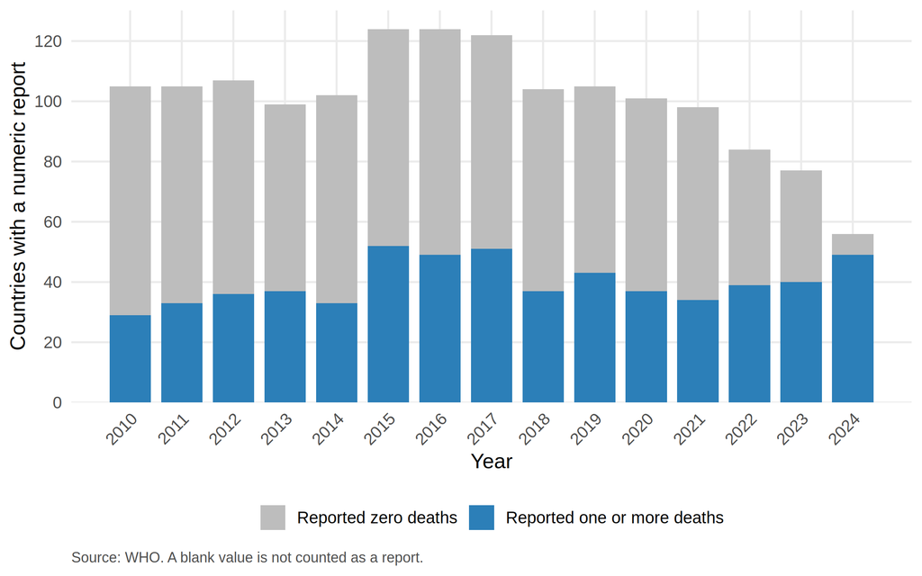

Figure 1: Countries with a numeric report of human rabies deaths, by year. Grey segments reported zero deaths. Blue segments reported at least one. Countries that did not report are not in the bars.

```r
coverage_long <- coverage |>
  select(year, countries_reporting_zero, countries_reporting_positive) |>
  pivot_longer(-year, names_to = "group", values_to = "countries") |>
  mutate(
    group = recode_values(
      group,
      "countries_reporting_zero" ~ "Reported zero deaths",
      "countries_reporting_positive" ~ "Reported one or more deaths"
    ),
    group = factor(
      group,
      levels = c("Reported zero deaths", "Reported one or more deaths")
    )
  )

ggplot(coverage_long, aes(x = year, y = countries, fill = group)) +
  geom_col(width = 0.8) +
  scale_x_continuous(breaks = 2010:2024) +
  scale_y_continuous(breaks = seq(0, 140, by = 20), expand = expansion(mult = c(0, 0.05))) +
  scale_fill_manual(values = c(
    "Reported zero deaths" = "#bdbdbd",
    "Reported one or more deaths" = "#2c7fb8"
  )) +
  labs(
    x = "Year",
    y = "Countries with a numeric report",
    fill = NULL,
    caption = "Source: WHO. A blank value is not counted as a report."
  ) +
  theme_rabies() +
  theme(axis.text.x = element_text(angle = 45, hjust = 1))
```

From 2010 through 2019, the number of countries with a numeric report ranged from 99 (2013) to 124 (2015 and 2016). The count was above 100 in 9 of those 10 years, not in every year. It was still 101 in 2020 and 98 in 2021, then 84 in 2022, 77 in 2023, and 56 in 2024. The drop is real. It is clearest after 2021, not in 2020 itself.

Many of those reports were zeros. In 2010, 76 of 105 reporting countries reported zero deaths. In 2024, 7 of 56 did. Later years sum deaths over a smaller set of countries, and a larger share of that set reported at least one death. Figure 1 shows both the shorter bars and that change in mix.

### 4.2 Reported deaths by year

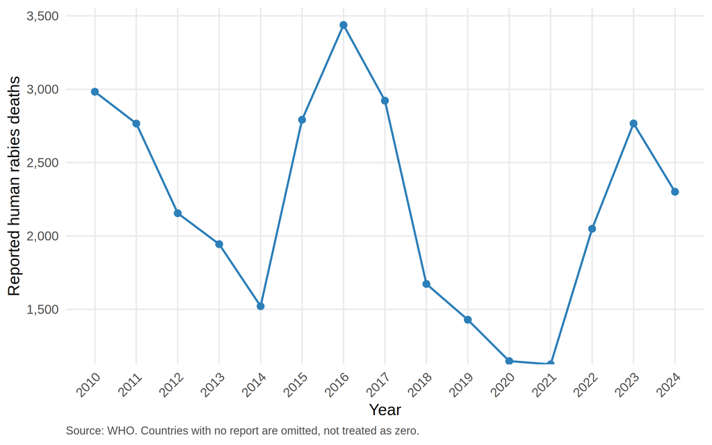

Figure 2: Sum of reported human rabies deaths among countries that submitted a number that year.

```r
ggplot(coverage, aes(x = year, y = reported_deaths)) +
  geom_line(linewidth = 0.8, color = "#2c7fb8") +
  geom_point(size = 2.2, color = "#2c7fb8") +
  scale_x_continuous(breaks = 2010:2024) +
  scale_y_continuous(labels = label_comma(), expand = expansion(mult = c(0, 0.05))) +
  labs(
    x = "Year",
    y = "Reported human rabies deaths",
    caption = "Source: WHO. Countries with no report are omitted, not treated as zero."
  ) +
  theme_rabies() +
  theme(axis.text.x = element_text(angle = 45, hjust = 1))
```

Figure 2 is the sum of the reports behind Table 5. Over the whole file that sum is 33,012 deaths. The three highest years were 2016 (3,438), 2010 (2,983), and 2017 (2,922). The lowest was 1,125 in 2021. In 2016, India (1,005), Kenya (727), and China (644) accounted for 2,376 of 3,438 reported deaths (69%).

The lower totals in 2018–2021 happened while between 98 and 105 countries were still reporting. That dip is not explained by a collapse in the number of reporting countries. After 2021, the summed total rises again and is highest in 2023 (2,767). The clearer drop in how many countries report comes in 2022–2024, during and after that rebound. Because the mix of countries also changed, a high total in a later year is not, by itself, evidence that deaths rose worldwide.

### 4.3 Countries with the most reported deaths

```r
top10 <- who |>
  filter(!is.na(deaths)) |>
  group_by(iso3, country) |>
  summarise(deaths = sum(deaths), .groups = "drop") |>
  arrange(desc(deaths)) |>
  slice_head(n = 10) |>
  left_join(country_rates |> select(iso3, years, rate_per_100k), by = "iso3") |>
  left_join(country_gdp |> select(iso3, gdp_per_capita), by = "iso3")

stopifnot(all(!is.na(top10$gdp_per_capita)))
stopifnot(all(!is.na(top10$rate_per_100k)))

leader <- top10 |> slice(1)
others_gdp <- top10$gdp_per_capita[top10$iso3 != leader$iso3]
others_min <- min(others_gdp)
others_max <- max(others_gdp)

top10_display <- top10 |>
  transmute(
    Country = country,
    `Reporting years` = years,
    Deaths = fmt_int(deaths),
    `Average GDP per capita` = fmt_gdp(gdp_per_capita),
    `Deaths per 100,000 person-years` = fmt_rate(rate_per_100k)
  )

kable(top10_display)
```

Table 6: Ten countries with the most reported human rabies deaths. Years are years with a numeric report. GDP per capita is the mean over years that also have a GDP value. The rate uses the same years as the rate sample.

| Country | Reporting years | Deaths | Average GDP per capita | Deaths per 100,000 person-years |
| --- | --- | --- | --- | --- |
| China | 14 | 10,524 | $9,067 | 0.0543 |
| India | 9 | 4,712 | $2,012 | 0.0378 |
| Philippines | 15 | 4,123 | $3,091 | 0.256 |
| Kenya | 5 | 1,543 | $1,757 | 0.602 |
| Myanmar | 15 | 1,508 | $1,253 | 0.194 |
| Viet Nam | 15 | 1,190 | $3,072 | 0.0837 |
| Angola | 4 | 945 | $2,860 | 0.76 |
| Liberia | 5 | 940 | $762 | 3.60 |
| Indonesia | 6 | 572 | $4,463 | 0.0343 |
| Bangladesh | 10 | 557 | $2,137 | 0.0336 |

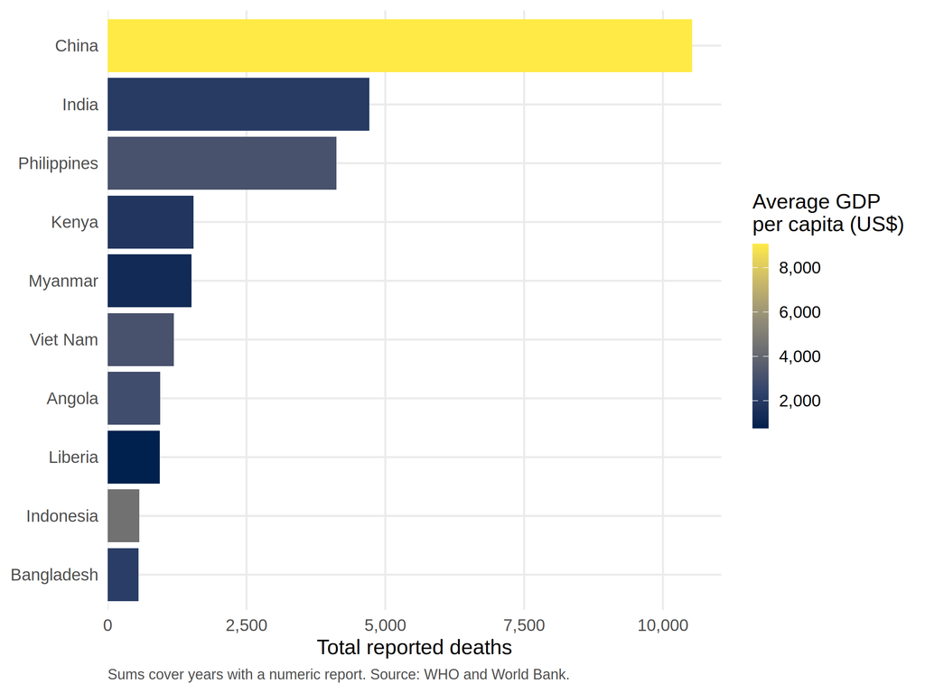

Figure 3: Ten countries with the most reported human rabies deaths, 2010–2024. Color is average GDP per capita over the years used for that country’s GDP.

```r
ggplot(
  top10,
  aes(x = reorder(country, deaths), y = deaths, fill = gdp_per_capita)
) +
  geom_col() +
  coord_flip() +
  scale_y_continuous(labels = label_comma(), expand = expansion(mult = c(0, 0.05))) +
  scale_fill_viridis_c(
    option = "cividis",
    breaks = c(2000, 4000, 6000, 8000),
    labels = label_comma()
  ) +
  guides(fill = guide_colorbar(barwidth = 0.7, barheight = 8)) +
  labs(
    x = NULL,
    y = "Total reported deaths",
    fill = "Average GDP\nper capita (US$)",
    caption = "Sums cover years with a numeric report. Source: WHO and World Bank."
  ) +
  theme_rabies() +
  theme(legend.position = "right")
```

China has the most reported deaths (10,524), over 14 reporting years. Its average GDP per capita was $9,067. The other nine countries in Table 6 ranged from $762 to $4,463. All nine are below $5,000. China is the high-GDP exception on this count list.

The same table shows why the counts are a poor ranking of risk. The rate column does not follow the death column. Reporting years also differ. India, Kenya, Angola, and several others are not in the file for all 15 years, so their totals are not a full-period census.

### 4.4 Population-adjusted rates

```r
top_rates <- country_rates |>
  arrange(desc(rate_per_100k), desc(deaths)) |>
  slice_head(n = 10)

top_rates_display <- top_rates |>
  transmute(
    Country = country,
    `Income group` = income_group,
    `Reporting years` = years,
    Deaths = fmt_int(deaths),
    `Person-years (millions)` = format(
      round(person_years / 1e6, 1),
      nsmall = 1,
      big.mark = ",",
      scientific = FALSE,
      trim = TRUE
    ),
    `Deaths per 100,000 person-years` = fmt_rate(rate_per_100k)
  )

count_not_rate <- top10 |>
  filter(!iso3 %in% top_rates$iso3) |>
  arrange(desc(deaths))
both <- top10 |>
  filter(iso3 %in% top_rates$iso3) |>
  arrange(desc(deaths))
both_phrase <- fmt_list(both$country)
not_rate_phrase <- fmt_list(count_not_rate$country)

leader_rank <- rank(-country_rates$rate_per_100k, ties.method = "min")[
  country_rates$iso3 == leader$iso3
]
leader_rate <- country_rates$rate_per_100k[country_rates$iso3 == leader$iso3]
hi_rate <- top_rates |> slice(1)

kable(top_rates_display)
```

Table 7: Ten highest reported death rates. Person-years are the sum of population in years with a numeric report. A rate based on one or two years, or on a handful of deaths, is unstable.

| Country | Income group | Reporting years | Deaths | Person-years (millions) | Deaths per 100,000 person-years |
| --- | --- | --- | --- | --- | --- |
| Liberia | Low income | 5 | 940 | 26.1 | 3.60 |
| South Sudan | Low income | 3 | 302 | 34.4 | 0.877 |
| Angola | Lower middle income | 4 | 945 | 124.3 | 0.76 |
| Kenya | Lower middle income | 5 | 1,543 | 256.2 | 0.602 |
| Lesotho | Lower middle income | 5 | 49 | 11.0 | 0.445 |
| Guinea-Bissau | Low income | 1 | 6 | 1.7 | 0.345 |
| Philippines | Upper middle income | 15 | 4,123 | 1,610.9 | 0.256 |
| Togo | Lower middle income | 1 | 21 | 8.4 | 0.25 |
| Ghana | Lower middle income | 4 | 298 | 122.5 | 0.243 |
| Burkina Faso | Low income | 9 | 422 | 184.4 | 0.229 |

The highest rate in this file is Liberia, at 3.60 reported deaths per 100,000 person-years, from 940 deaths over 5 reporting years. That is not a 15-year average. Several other countries near the top of Table 7 also rest on a short run of years or on very few deaths. Those ranks can move if another year is reported.

China, which leads the death totals, ranks 34 of 169 countries on the rate (0.0543 per 100,000 person-years). Countries in both top-10 lists are Philippines, Kenya, Angola, and Liberia. Countries in the top 10 by deaths but not by rate are China, India, Myanmar, Viet Nam, Indonesia, and Bangladesh. Population adjustment changes the reading of the count list. It does not say the count list is unimportant: those are still the countries that reported the most deaths.

South Sudan is high on the rate list and has no GDP per capita in these years, so it is in the rate and income results and not in the GDP model. Eritrea is in the same position and is not in the top 10 rates.

### 4.5 GDP per capita

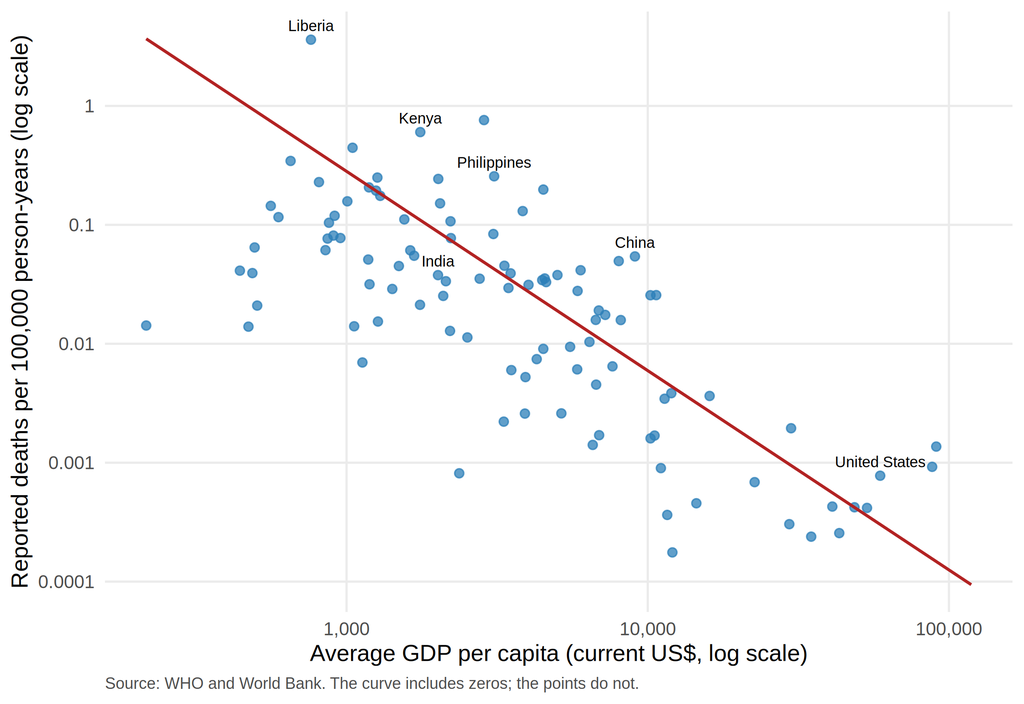

Figure 4: Reported death rate and average GDP per capita. Points are countries with at least one reported death. The curve is the fitted mean rate from the negative binomial model, which also includes countries with zero deaths. Those countries are omitted here because the rate axis is logarithmic.

```r
b0 <- coef(m_gdp)[["(Intercept)"]]
b1 <- coef(m_gdp)[["log_gdp"]]
gdp_grid <- tibble(
  gdp_per_capita = exp(seq(
    log(min(country_gdp$gdp_per_capita)),
    log(max(country_gdp$gdp_per_capita)),
    length.out = 200
  ))
)
gdp_grid$rate_per_100k <- exp(b0 + b1 * log(gdp_grid$gdp_per_capita)) * 1e5

label_points <- country_gdp |>
  filter(iso3 %in% c("CHN", "IND", "PHL", "LBR", "KEN", "USA"), deaths > 0) |>
  mutate(
    label = recode_values(
      iso3,
      "CHN" ~ "China",
      "IND" ~ "India",
      "PHL" ~ "Philippines",
      "LBR" ~ "Liberia",
      "KEN" ~ "Kenya",
      "USA" ~ "United States"
    )
  )

ggplot(country_gdp_pos, aes(x = gdp_per_capita, y = rate_per_100k)) +
  geom_point(size = 2, alpha = 0.75, color = "#2c7fb8") +
  geom_line(
    data = gdp_grid,
    aes(x = gdp_per_capita, y = rate_per_100k),
    color = "#b22222",
    linewidth = 0.8
  ) +
  geom_text(
    data = label_points,
    aes(label = label),
    size = 3,
    vjust = -0.8,
    check_overlap = TRUE
  ) +
  scale_x_log10(labels = label_comma()) +
  scale_y_log10(labels = label_number(drop0trailing = TRUE)) +
  labs(
    x = "Average GDP per capita (current US$, log scale)",
    y = "Reported deaths per 100,000 person-years (log scale)",
    caption = "Source: WHO and World Bank. The curve includes zeros; the points do not."
  ) +
  theme_rabies()
```

```r
spearman_display <- tibble(
  Comparison = c(
    "Death rate",
    "Death rate",
    "Cumulative deaths"
  ),
  `Zero-death countries` = c("Included", "Excluded", "Excluded"),
  Countries = c(
    nrow(country_gdp),
    nrow(country_gdp_pos),
    nrow(country_gdp_pos)
  ),
  rho = c(
    fmt_rho(spearman_rate$estimate),
    fmt_rho(spearman_rate_pos$estimate),
    fmt_rho(spearman_deaths_pos$estimate)
  ),
  `p value` = c(
    fmt_p(spearman_rate$p.value),
    fmt_p(spearman_rate_pos$p.value),
    fmt_p(spearman_deaths_pos$p.value)
  )
)

kable(spearman_display)
```

Table 8: Spearman rank correlation between average GDP per capita and either the death rate or the cumulative death count. The count row keeps the comparison used in the first draft of this report.

| Comparison | Zero-death countries | Countries | rho | p value |
| --- | --- | --- | --- | --- |
| Death rate | Included | 167 | -0.71 | < 0.001 |
| Death rate | Excluded | 103 | -0.70 | < 0.001 |
| Cumulative deaths | Excluded | 103 | -0.47 | < 0.001 |

```r
gdp_model_display <- bind_rows(
  doubling_rr(m_gdp) |>
    mutate(
      Model = "Main model, zero-death countries included",
      Countries = nrow(country_gdp),
      `Countries with zero deaths` = sum(country_gdp$deaths == 0)
    ),
  doubling_rr(m_gdp_pos) |>
    mutate(
      Model = "Sensitivity, zero-death countries excluded",
      Countries = nrow(country_gdp_pos),
      `Countries with zero deaths` = 0L
    ),
  doubling_rr(m_gdp_region) |>
    mutate(
      Model = "Sensitivity, zeros included and region added",
      Countries = nrow(country_gdp),
      `Countries with zero deaths` = sum(country_gdp$deaths == 0)
    )
) |>
  transmute(
    Model,
    Countries,
    `Countries with zero deaths`,
    `Rate ratio for a doubling of GDP per capita` = fmt_rr(rr),
    `95% CI` = paste0(fmt_rr(lo), " to ", fmt_rr(hi)),
    `p value` = fmt_p(p)
  )

kable(gdp_model_display)
```

Table 9: Negative binomial models for reported deaths with a population offset. The rate ratio is for a doubling of GDP per capita. Intervals are Wald 95% confidence intervals.

| Model | Countries | Countries with zero deaths | Rate ratio for a doubling of GDP per capita | 95% CI | p value |
| --- | --- | --- | --- | --- | --- |
| Main model, zero-death countries included | 167 | 64 | 0.31 | 0.27 to 0.36 | < 0.001 |
| Sensitivity, zero-death countries excluded | 103 | 0 | 0.38 | 0.33 to 0.44 | < 0.001 |
| Sensitivity, zeros included and region added | 167 | 64 | 0.41 | 0.35 to 0.49 | < 0.001 |

Among the 167 countries with GDP per capita, the Spearman correlation between GDP per capita and the death rate is -0.71 (p < 0.001). Dropping the 64 countries with zero deaths leaves it at -0.70 (p < 0.001, 103 countries). The association does not depend on keeping the zeros. On the cumulative-count scale, among countries with at least one death, rho is -0.47 (p < 0.001). That count correlation is close to the one in the first draft of this report. The rate correlation is the fairer summary, because a large country can report many deaths at a modest rate.

In the main negative binomial model, a doubling of GDP per capita is associated with a rate ratio of 0.31 (95% CI 0.27 to 0.36). Excluding zero-death countries, the ratio is 0.38 (0.33 to 0.44). Adding region, it is 0.41 (0.35 to 0.49). The direction is the same in all three fits. This is not an estimate of what would happen if GDP rose. GDP is standing in for a bundle of conditions that this file does not measure: dog vaccination, post-exposure prophylaxis, health services, and whether a death is recognized and reported. It is also an ecological association. A relationship between country averages does not show that lower-income people within a country have higher risk.

Figure 4 should be read with that caveat. The red curve is the mean rate from the main model, not a straight-line fit drawn through the logged points. Countries with a rate of zero cannot be drawn on a log scale. There are 64 of them, and they are in the model.

### 4.6 Income group

```r
income_rr <- tidy(m_inc, conf.int = TRUE, exponentiate = TRUE) |>
  filter(term != "(Intercept)") |>
  mutate(income_group = sub("^income_f", "", term)) |>
  select(income_group, estimate, conf.low, conf.high, p.value)

income_summary <- country_rates |>
  group_by(income_group) |>
  summarise(
    n = n(),
    zeros = sum(deaths == 0),
    deaths = sum(deaths),
    median_rate = median(rate_per_100k),
    pooled_rate = sum(deaths) / sum(person_years) * 1e5,
    .groups = "drop"
  ) |>
  left_join(income_rr, by = "income_group") |>
  mutate(income_group = factor(income_group, levels = income_levels)) |>
  arrange(income_group)

income_display <- income_summary |>
  transmute(
    `Income group` = as.character(income_group),
    Countries = n,
    `Countries with zero deaths` = zeros,
    `Reported deaths` = fmt_int(deaths),
    `Median rate` = fmt_rate(median_rate),
    `Pooled rate` = fmt_rate(pooled_rate),
    `Rate ratio vs high income` = if_else(is.na(estimate), "1 (reference)", fmt_rr(estimate)),
    `95% CI` = if_else(is.na(estimate), "—", paste0(fmt_rr(conf.low), " to ", fmt_rr(conf.high))),
    `p value` = if_else(is.na(estimate), "—", fmt_p(p.value))
  )

umi_deaths <- income_summary$deaths[income_summary$income_group == "Upper middle income"]
china_phl_deaths <- sum(country_rates$deaths[country_rates$iso3 %in% c("CHN", "PHL")])
china_deaths <- sum(country_rates$deaths[country_rates$iso3 == "CHN"])
eap_deaths <- sum(country_rates$deaths[country_rates$wb_region == "East Asia & Pacific"])
hi_leader <- country_rates |>
  filter(income_group == "High income") |>
  arrange(desc(deaths)) |>
  slice(1)

kable(income_display)
```

Table 10: Reported deaths by World Bank income group. The pooled rate is total deaths divided by total person-years. The rate ratio is from a negative binomial model with a population offset, compared with high income. The model ratio is more sensitive to high-rate countries than the pooled rate is.

| Income group | Countries | Countries with zero deaths | Reported deaths | Median rate | Pooled rate | Rate ratio vs high income | 95% CI | p value |
| --- | --- | --- | --- | --- | --- | --- | --- | --- |
| Low income | 23 | 2 | 3,489 | 0.0645 | 0.109 | 562 | 254 to 1,302 | < 0.001 |
| Lower middle income | 37 | 2 | 11,610 | 0.0453 | 0.0559 | 247 | 120 to 514 | < 0.001 |
| Upper middle income | 51 | 18 | 17,800 | 0.0026 | 0.0473 | 46 | 23 to 91 | < 0.001 |
| High income | 58 | 42 | 110 | 0 | 0.000789 | 1 (reference) | — | — |

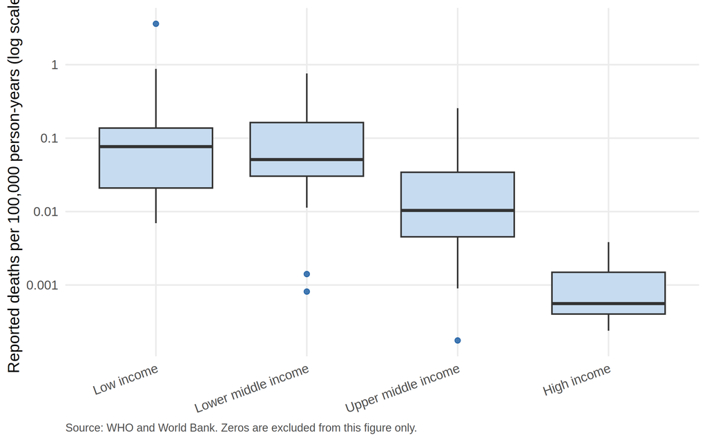

Figure 5: Country death rates by income group, among countries with at least one reported death. The axis is logarithmic. Countries that reported only zeros are not plotted; they are counted in the income table.

```r
ggplot(
  country_rates |> filter(deaths > 0),
  aes(x = factor(income_group, levels = income_levels), y = rate_per_100k)
) +
  geom_boxplot(fill = "#c6dbef", outlier.color = "#08519c", outlier.alpha = 0.75) +
  scale_y_log10(labels = label_number(drop0trailing = TRUE)) +
  labs(
    x = NULL,
    y = "Reported deaths per 100,000 person-years (log scale)",
    caption = "Source: WHO and World Bank. Zeros are excluded from this figure only."
  ) +
  theme_rabies() +
  theme(axis.text.x = element_text(angle = 20, hjust = 1))
```

High-income countries reported 110 deaths in this sample, and 42 of 58 countries reported none. The median rate in that group is 0. The pooled rate is 0.000789 per 100,000 person-years, compared with 0.109 in the low-income group and 0.0559 in the lower-middle-income group.

The pooled low-income rate is about 138 times the pooled high-income rate. The negative binomial rate ratio is larger than that (562, 95% CI 254 to 1,302). The model is pulled by countries with very high rates, and by the many high-income zeros. The pooled rates and the medians are the better description of the size of the gap. The model supports a narrower statement: low-income and lower-middle-income countries still have higher rates than high-income countries when zeros are kept and population is in the offset.

Upper-middle-income countries reported the most deaths (17,800), but the median rate in that group is low (0.0026). China and the Philippines account for 14,647 of those deaths (82%). The group is not one experience. High-income countries stand apart on the median and on the share of countries reporting zero. The other three groups are not interchangeable with each other.

The income label is the World Bank group in the metadata vintage dated 13 July 2026, applied to every year. The largest high-income death total in this file is Russian Federation (61). That classification is the file’s, not a judgment about the income group in every year from 2010 to 2024.

### 4.7 Region

```r
region_rr <- tidy(m_reg, conf.int = TRUE, exponentiate = TRUE) |>
  filter(term != "(Intercept)") |>
  mutate(wb_region = sub("^region_f", "", term)) |>
  select(wb_region, estimate, conf.low, conf.high, p.value)

region_summary <- country_rates |>
  group_by(wb_region) |>
  summarise(
    n = n(),
    zeros = sum(deaths == 0),
    deaths = sum(deaths),
    median_rate = median(rate_per_100k),
    pooled_rate = sum(deaths) / sum(person_years) * 1e5,
    .groups = "drop"
  ) |>
  left_join(region_rr, by = "wb_region") |>
  arrange(desc(pooled_rate))

region_display <- region_summary |>
  transmute(
    Region = wb_region,
    Countries = n,
    `Countries with zero deaths` = zeros,
    `Reported deaths` = fmt_int(deaths),
    `Median rate` = fmt_rate(median_rate),
    `Pooled rate` = fmt_rate(pooled_rate),
    `Rate ratio vs Europe & Central Asia` = if_else(
      is.na(estimate), "1 (reference)", fmt_rr(estimate)
    ),
    `95% CI` = if_else(
      is.na(estimate), "—", paste0(fmt_rr(conf.low), " to ", fmt_rr(conf.high))
    ),
    `p value` = if_else(is.na(estimate), "—", fmt_p(p.value))
  )

na_phrase <- fmt_list(
  country_rates$country[country_rates$wb_region == "North America"][
    order(country_rates$country[country_rates$wb_region == "North America"])
  ]
)

kable(region_display)
```

Table 11: Reported deaths by World Bank region. The rate ratio is from a negative binomial model with a population offset, compared with Europe and Central Asia. North America here is Canada and the United States only.

| Region | Countries | Countries with zero deaths | Reported deaths | Median rate | Pooled rate | Rate ratio vs Europe & Central Asia | 95% CI | p value |
| --- | --- | --- | --- | --- | --- | --- | --- | --- |
| Sub-Saharan Africa | 43 | 7 | 7,186 | 0.0766 | 0.109 | 35 | 17 to 73 | < 0.001 |
| East Asia & Pacific | 18 | 7 | 18,249 | 0.0158 | 0.0665 | 7.37 | 2.96 to 21 | < 0.001 |
| South Asia | 6 | 1 | 5,839 | 0.0384 | 0.0396 | 8.29 | 2.25 to 54 | 0.007 |
| Middle East & North Africa | 20 | 7 | 1,059 | 0.0124 | 0.0287 | 3.60 | 1.48 to 9.78 | 0.007 |
| Latin America & Caribbean | 33 | 18 | 348 | 0 | 0.00409 | 0.88 | 0.38 to 2.15 | 0.783 |
| Europe & Central Asia | 47 | 24 | 301 | 0 | 0.00277 | 1 (reference) | — | — |
| North America | 2 | 0 | 27 | 0.0006 | 0.000732 | 0.10 | 0.01 to 4.78 | 0.069 |

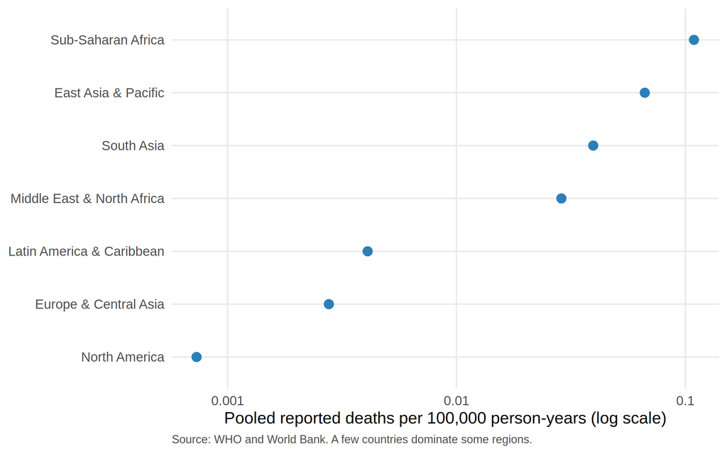

Figure 6: Pooled reported death rate by World Bank region. Each point is total reported deaths divided by total person-years. The axis is logarithmic.

```r
ggplot(region_summary, aes(x = pooled_rate, y = reorder(wb_region, pooled_rate))) +
  geom_point(size = 3, color = "#2c7fb8") +
  scale_x_log10(labels = label_number(drop0trailing = TRUE)) +
  labs(
    x = "Pooled reported deaths per 100,000 person-years (log scale)",
    y = NULL,
    caption = "Source: WHO and World Bank. A few countries dominate some regions."
  ) +
  theme_rabies()
```

Sub-Saharan Africa has the highest pooled rate (0.109 per 100,000 person-years). East Asia and Pacific has the most reported deaths (18,249), and China alone is 58% of that total, so the regional total is not the rate in a typical country there. The median rate in East Asia and Pacific is 0.0158, below the Sub-Saharan African median of 0.0766.

South Asia’s pooled rate is high and the model interval is wide. The region has 6 countries in this sample. Europe and Central Asia and Latin America and the Caribbean are both low, and the model interval for Latin America and the Caribbean includes a rate ratio of 1 relative to Europe and Central Asia. North America in this World Bank grouping is 2 countries (Canada and United States of America), both with very low rates. The interval for that comparison is wide and also includes 1. Two countries are not a basis for a regional claim.

The pooled Sub-Saharan African rate is about 39 times the pooled rate in Europe and Central Asia. The model rate ratio is 35 (95% CI 17 to 73). Those two summaries are closer to each other here than the income-group model was to its pooled rates. Geography is still not an explanation by itself. Regions with higher rates also tend to have lower GDP per capita, and the GDP association remained after region was added (Table 9).

## 5 Discussion

On the count list, wealthier countries generally had fewer reported deaths, with China as the exception: the most deaths, and a higher average GDP per capita than the other nine ($9,067, against $762 to $4,463). Yao, Zhang, and Hanmer (2004) described persistent rural poverty and inequality in China during an earlier period of growth. That is one possible context for a country with a relatively high GDP per capita and a large number of reported rabies deaths, but this analysis does not measure within-country inequality, and it cannot determine whether that history explains the rabies reports. On the rate scale China is not near the top. It ranks 34 of 169. The Philippines stays high on both lists. The other countries that do both are Philippines, Kenya, Angola, and Liberia. The GDP results agree in direction whether zeros are kept or dropped, and they agree after a simple adjustment for region. That still does not make GDP the cause. Countries with fewer resources may have less access to dog vaccination, diagnostics, and post-exposure treatment, and they may also differ in how completely deaths are recorded. Any of those could produce the pattern in Figure 4.

High-income countries stand apart: most of them reported no deaths, and the pooled rate is far below the other groups. Upper-middle-income countries are the awkward group in the middle of that story. They reported the most deaths, and China and the Philippines are 82% of that total, while the median upper-middle-income country has a much lower rate. The Philippines can report hundreds of deaths in a year inside a group that also contains countries with few or none. Low-income and lower-middle-income countries have higher median and pooled rates than high-income countries. The very large model rate ratios against high income are a comparison with a rate near zero, so the pooled rates in Table 10 are the numbers to remember. Economic status is associated with the reported rate. It is not a complete account of it.

By region, Sub-Saharan Africa has the highest pooled rate, and East Asia and Pacific has the highest death total largely because of China. South Asia is high on a small number of countries. Europe and Central Asia, Latin America and the Caribbean, and North America are low, with the North America comparison too thin to lean on. Many of the countries in the higher-rate regions also have lower GDP per capita. Limited resources can affect surveillance, treatment, and animal vaccination, so the regional pattern and the income pattern are overlapping descriptions rather than separate causes. The practical point is unchanged. More complete surveillance, and better access to prevention and treatment in the countries with higher reported rates, would make these comparisons more reliable and more useful for deciding where support is needed.

## 6 Limitations

The WHO values are reported deaths, not the number of people who died of rabies. Blank cells were left as “no report.” They were not filled in as zeros. Published estimates of the global burden of endemic canine rabies are on the order of 59,000 deaths a year (Hampson et al., 2015), far above the roughly 1,125 to 3,438 deaths a year summed in this file. Most deaths are never laboratory-confirmed or reported. This series also starts in 2010, so it cannot describe a longer historical trend.

Coverage falls after 2021, and countries do not report every year. Person-years cover only years with a numeric report. A country that reports in its worst years will look worse than one that reports every year. Rates based on a few deaths, or on one or two years, are unstable. Liberia’s place at the top of the rate list, and several of the other high rates, should be read next to the death count and the number of years.

Income group and region are one World Bank label per country, from metadata dated with the 13 July 2026 extract, applied to the whole period. Countries move between income groups. That history is not in this analysis. GDP per capita is in current US dollars, not purchasing-power parity. Total GDP was not used. French Guiana (3 reported deaths) has no World Bank country code and is left out of the rate comparisons. South Sudan and Eritrea have population and an income group but no GDP per capita in the years they reported, so they stay in the rate and income results and drop out of the GDP results. Some other country-years are missing GDP only (Table 4).

The models give each country one negative binomial count and a population offset. They are not a year-by-year time series, and they are not causal. Income, region, and GDP describe overlapping groups of countries. Adding region to the GDP model is a sensitivity check, not a full attempt to separate those factors. Because the data are country averages, the ecological fallacy applies: the results do not identify which people within a country are at higher risk. The main GDP model keeps zero-death countries. Dropping them did not change the direction of the association. The log-scale figures omit zeros because a logarithm of zero is undefined. Those figures are not the model.

## 7 Conclusion

A few patterns are consistent in these reported data, and several tempting readings are not. The yearly totals fluctuate, and the number of countries behind them changes, especially after 2021, so the line in Figure 2 is not a clean trend in global deaths. Countries with higher GDP per capita, and high-income countries, have lower reported death rates. The count of deaths tells a related but not identical story: China and India lead the counts and do not lead the rates, and China’s GDP per capita sits above the other countries with the largest death totals. Sub-Saharan Africa has the highest pooled rate. East Asia and Pacific and the upper-middle-income group have high death totals that are concentrated in a few countries. None of this isolates a single cause. Surveillance, access to prophylaxis, dog vaccination, and population size all sit between the economic variables and the reported numbers. Improving reporting, and access to prevention and treatment in countries with higher reported rates, would make the data more complete and would put public health resources closer to the populations these reports already flag.

## 8 References

Dietzschold, B., Li, J., Faber, M., & Schnell, M. (2008). Concepts in the pathogenesis of rabies. *Future Virology, 3*(5), 481–490. https://doi.org/10.2217/17460794.3.5.481

Hampson, K., Coudeville, L., Lembo, T., Sambo, M., Kieffer, A., Attlan, M., Barrat, J., Blanton, J. D., Briggs, D. J., Cleaveland, S., Costa, P., Freuling, C. M., Hiby, E., Knopf, L., Leanes, F., Meslin, F.-X., Metlin, A., Miranda, M. E., Müller, T., Nel, L. H., Recuenco, S., Rupprecht, C. E., Schumacher, C., Taylor, L., Vigilato, M. A. N., Zinsstag, J., & Dushoff, J. (2015). Estimating the global burden of endemic canine rabies. *PLOS Neglected Tropical Diseases, 9*(4), Article e0003709. https://doi.org/10.1371/journal.pntd.0003709

Pieracci, E. G., Pearson, C. M., Wallace, R. M., Blanton, J. D., Whitehouse, E. R., Ma, X., Stauffer, K., Chipman, R. B., & Olson, V. (2019). Vital signs: Trends in human rabies deaths and exposures—United States, 1938–2018. *Morbidity and Mortality Weekly Report, 68*(23), 524–528. https://doi.org/10.15585/mmwr.mm6823e1

Terryn, S., Francart, A., Rommelaere, H., Stortelers, C., & Van Gucht, S. (2016). Post-exposure treatment with anti-rabies VHH and vaccine significantly improves protection of mice from lethal rabies infection. *PLOS Neglected Tropical Diseases, 10*(8), Article e0004902. https://doi.org/10.1371/journal.pntd.0004902

World Bank. (n.d.-a). *GDP per capita (current US$)* [Data set]. World Development Indicators. https://data.worldbank.org/indicator/NY.GDP.PCAP.CD

World Bank. (n.d.-b). *Population, total* [Data set]. World Development Indicators. https://data.worldbank.org/indicator/SP.POP.TOTL

World Health Organization. (n.d.). *Reported number of human rabies deaths* [Data set]. Global Health Observatory. https://www.who.int/data/gho/data/indicators/indicator-details/GHO/reported-number-of-human-rabies-deaths

Yao, S., Zhang, Z., & Hanmer, L. (2004). Growing inequality and poverty in China. *China Economic Review, 15*(2), 145–163. https://doi.org/10.1016/j.chieco.2003.09.002

## 9 Reproduce this report

The repository README has the install steps. In short, from the project root, with R and Quarto available: install the `renv` package, run `renv::restore()`, then `quarto render`. The rendered report is written to `docs/`. Package versions for this copy are in `renv.lock` and in the session note below. The code and this write-up are under the MIT license. The WHO and World Bank files are not.